# MidtermProject

## S&P Financial Data

```python
import numpy as np
import matplotlib.pyplot as plt
```

### Load and Read the downloaded .txt file

(from https://datahub.io/core/s-and-p-500-companies-financials#pandas)

.csv file converted to tab delimited text file since string columns contain comma characters.

```python
path = r"C:/Users/Kanna/Documents/Rutgers Grad/Spring 2023/BINF5900 DATA SCIENCE PROG/AdvPy_Project/"

sp500 = np.genfromtxt(path+"constituents-financials_csv_new.txt",
                   delimiter='\t',
                   skip_header = 1,
                   filling_values=0,
                   dtype = {'names': ('Symbol', 'Name', 'Sector', 'Price',
                                      'Price_Earnings','DividendYield','Earnings_Share',
                                      '52WeekLow','52WeekHigh','MarketCap',
                                      'EBITDA','Price_Sales', 'Price_Book', 'SECFilings'),
                            'formats': ('S5', 'S50', 'S30', 'f8',
                                        'f8', 'f8', 'f8',
                                        'f8', 'f8', 'f8',
                                        'f8', 'f8', 'f8', 'S150')})
```

```python
# Checking the data was loaded correctly
print("SP500 Data (first 10 rows):")
print(sp500[:10])

# To display the rows
print("\nDisplaying a few Rows to cross-check:")
print(sp500[24])
print(sp500[248])
print(sp500[426])

# To display the columns
print("\nDisplaying Column Names")
colnames = sp500.dtype.names
print(colnames)
```

```
SP500 Data (first 10 rows):
[(b'MMM', b'3M Company', b'Industrials', 222.89,  24.31, 2.3328617 , 7.92, 175.49 , 259.77 , 1.39000000e+11, 9.048000e+09,  4.3902707, 11.34, b'http://www.sec.gov/cgi-bin/browse-edgar?action=getcompany&CIK=MMM')
 (b'AOS', b'A.O. Smith Corp', b'Industrials',  60.24,  27.76, 1.1479592 , 1.7 ,  48.925,  68.39 , 1.07834199e+10, 6.010000e+08,  3.5754826,  6.35, b'http://www.sec.gov/cgi-bin/browse-edgar?action=getcompany&CIK=AOS')
 (b'ABT', b'Abbott Laboratories', b'Health Care',  56.27,  22.51, 1.9089824 , 0.26,  42.28 ,  64.6  , 1.02000000e+11, 5.744000e+09,  3.7404804,  3.19, b'http://www.sec.gov/cgi-bin/browse-edgar?action=getcompany&CIK=ABT')
 (b'ABBV', b'AbbVie Inc.', b'Health Care', 108.48,  19.41, 2.4995599 , 3.29,  60.05 , 125.86 , 1.81000000e+11, 1.031000e+10,  6.291571 , 26.14, b'http://www.sec.gov/cgi-bin/browse-edgar?action=getcompany&CIK=ABBV')
 (b'ACN', b'Accenture plc', b'Information Technology', 150.51,  25.47, 1.7144699 , 5.44, 114.82 , 162.6  , 9.87658556e+10, 5.643228e+09,  2.604117 , 10.62, b'http://www.sec.gov/cgi-bin/browse-edgar?action=getcompany&CIK=ACN')
 (b'ATVI', b'Activision Blizzard', b'Information Technology',  65.83,  31.8 , 0.43190324, 1.28,  38.93 ,  74.945, 5.25186681e+10, 2.704000e+09, 10.59512  ,  5.16, b'http://www.sec.gov/cgi-bin/browse-edgar?action=getcompany&CIK=ATVI')
 (b'AYI', b'Acuity Brands Inc', b'Industrials', 145.41,  18.22, 0.35118526, 7.43, 142.   , 225.36 , 6.24237770e+09, 5.878000e+08,  1.7953473,  3.55, b'http://www.sec.gov/cgi-bin/browse-edgar?action=getcompany&CIK=AYI')
 (b'ADBE', b'Adobe Systems Inc', b'Information Technology', 185.16,  52.31, 0.        , 3.39, 114.451, 204.45 , 9.45502143e+10, 2.538040e+09, 13.092818 , 11.06, b'http://www.sec.gov/cgi-bin/browse-edgar?action=getcompany&CIK=ADBE')
 (b'AAP', b'Advance Auto Parts', b'Consumer Discretionary', 109.63,  19.54, 0.21832074, 6.19,  78.81 , 169.55 , 8.12361187e+09, 8.539410e+08,  1.1301061,  2.51, b'http://www.sec.gov/cgi-bin/browse-edgar?action=getcompany&CIK=AAP')
 (b'AMD', b'Advanced Micro Devices Inc', b'Information Technology',  11.22, 187.  , 0.        , 0.03,   9.7  ,  15.65 , 1.11916638e+10, 3.390000e+08,  2.1091955, 21.47, b'http://www.sec.gov/cgi-bin/browse-edgar?action=getcompany&CIK=AMD')]

Displaying a few Rows to cross-check:
(b'ADS', b'Alliance Data Systems', b'Information Technology', 240.6, 13.02, 0.9240122, 14.13, 209., 278.33, 1.36326086e+10, 2.1432e+09, 1.7282298, 8.28, b'http://www.sec.gov/cgi-bin/browse-edgar?action=getcompany&CIK=ADS')
(b'ICE', b'Intercontinental Exchange', b'Financials', 67., 22.95, 5.4298644, 2.37, 56.8, 76.1378, 4.13730512e+10, 3.103e+09, 9.619987, 2.62, b'http://www.sec.gov/cgi-bin/browse-edgar?action=getcompany&CIK=ICE')
(b'SYF', b'Synchrony Financial', b'Financials', 34.98, 13.35, 1.6, 2.41, 26.01, 40.59, 2.889375e+10, 0., 2.1096623, 1.97, b'http://www.sec.gov/cgi-bin/browse-edgar?action=getcompany&CIK=SYF')

Displaying Column Names
('Symbol', 'Name', 'Sector', 'Price', 'Price_Earnings', 'DividendYield', 'Earnings_Share', '52WeekLow', '52WeekHigh', 'MarketCap', 'EBITDA', 'Price_Sales', 'Price_Book', 'SECFilings')
```

### Cleaning the Data

```python
# Count total elements where Dividend Yield = 0
print("Count total elements where Dividend Yield = 0")
print(np.size(np.where(sp500['DividendYield'] == 0.)))

print('--------')

# Count total elements where EBITDA = 0
print("Count total elements where EBITDA = 0")
print(np.size(np.where(sp500['EBITDA'] == 0.)))
```

```
Count total elements where Dividend Yield = 0
86
--------
Count total elements where EBITDA = 0
58
```

```python
# Replacing numeric columns zero values with nan
# (required so stats functions can ignore these missing values)
for coln in colnames:
    if np.issubdtype(sp500[coln].dtype, np.number):
        # True if column dtype is numeric
        sp500[coln][(sp500[coln] == 0.)] = 'nan'
    elif np.issubdtype(sp500[coln].dtype, np.string_):
        # True if column dtype is string
        sp500[coln][(sp500[coln] in ['0', ' '])] = '**NA**'
```

```python
# Validate the same columns (Dividend Yield & EBITDA) for values equal to 0
print("Count total elements where Dividend Yield = 0")
print(np.where(sp500['DividendYield'] == 0.))

print('--------')

print("Count total elements where EBITDA = 0")
print(np.where(sp500['EBITDA'] == 0.))
```

```
Count total elements where Dividend Yield = 0
(array([], dtype=int64),)
--------
Count total elements where EBITDA = 0
(array([], dtype=int64),)
```

```python
# Validate the same columns for nan missing values. Display total amount nan values.
# Count should be the same.
print("Count total elements where Dividend Yield = nan")
print(np.size(np.argwhere(np.isnan(sp500['DividendYield']))))

print('--------')

print("Count total elements where EBITDA = nan")
print(np.size(np.argwhere(np.isnan(sp500['EBITDA']))))
```

```
Count total elements where Dividend Yield = nan
86
--------
Count total elements where EBITDA = nan
58
```

```python
# Print columns where missing nan values exist
col_misval = []

for coln in colnames:
    if np.issubdtype(sp500[coln].dtype, np.number):
        if np.isnan(sp500[coln]).any():
            # To capture columns where nan
            col_misval.append(coln)
            # Count of missing values
            count = np.size(np.argwhere(np.isnan(sp500[coln])))
            # Identify where missing values exist
            idx = np.argwhere(np.isnan(sp500[coln]))

            print("COLUMN:", coln, "has", count, "missing nan values.")
            print("\tIndices where missing:", idx.flatten())
            print("\tTICKER SYMBOL:", sp500[idx]["Symbol"].flatten(), '\n')

    else:
        if np.any(sp500[coln] == b'**NA**'):
            print("Column:", coln, "has missing values.\n")
```

```
COLUMN: Price_Earnings has 2 missing nan values.
	Indices where missing: [360 430]
	TICKER SYMBOL: [b'PRGO' b'TPR']

COLUMN: DividendYield has 86 missing nan values.
	Indices where missing: [  7   9  16  20  21  27  28  30  46  59  61  70  72  78  79  86  90  94
  96  97 100 103 104 106 116 125 140 147 148 149 151 160 163 166 167 170
 183 186 187 194 207 228 232 241 242 244 245 254 256 277 284 299 306 308
 310 313 317 321 326 328 341 345 355 362 372 382 384 390 392 403 404 422
 427 430 450 451 457 458 459 461 464 470 472 473 475 483]
	TICKER SYMBOL: [b'ADBE' b'AMD' b'AKAM' b'ALXN' b'ALGN' b'GOOGL' b'GOOG' b'AMZN' b'ANSS'
 b'ADSK' b'AZO' b'BRK.B' b'BIIB' b'BSX' b'BHF' b'CDNS' b'KMX' b'CBG'
 b'CELG' b'CNC' b'CERN' b'CHTR' b'CHK' b'CMG' b'CTXS' b'CXO' b'DVA'
 b'DISCA' b'DISCK' b'DISH' b'DLTR' b'ETFC' b'EBAY' b'EW' b'EA' b'EVHC'
 b'ESRX' b'FFIV' b'FB' b'FISV' b'IT' b'HSIC' b'HOLX' b'IDXX' b'INFO'
 b'ILMN' b'INCY' b'ISRG' b'IQV' b'LH' b'LKQ' b'MAT' b'MTD' b'KORS' b'MU'
 b'MHK' b'MNST' b'MYL' b'NFLX' b'NFX' b'NCLH' b'ORLY' b'PYPL' b'PCG'
 b'PCLN' b'QRVO' b'PWR' b'RHT' b'REGN' b'CRM' b'SBAC' b'SRCL' b'SNPS'
 b'TPR' b'TDG' b'TRIP' b'ULTA' b'UAA' b'UA' b'UAL' b'URI' b'VAR' b'VRSN'
 b'VRSK' b'VRTX' b'WAT']

COLUMN: Earnings_Share has 1 missing nan values.
	Indices where missing: [433]
	TICKER SYMBOL: [b'FTI']

COLUMN: EBITDA has 58 missing nan values.
	Indices where missing: [ 13  19  26  34  35  38  47  57  66  68  70  79  88 102 107 109 111 114
 115 123 146 160 178 192 216 223 238 239 263 267 283 286 289 305 319 324
 339 357 360 367 373 375 377 387 393 421 424 426 430 436 441 447 455 467
 478 485 499 503]
	TICKER SYMBOL: [b'AFL' b'ARE' b'ALL' b'AXP' b'AIG' b'AMP' b'ANTM' b'AIZ' b'BAC' b'BBT'
 b'BRK.B' b'BHF' b'COF' b'SCHW' b'CB' b'CI' b'CINF' b'C' b'CFG' b'CMA'
 b'DFS' b'ETFC' b'RE' b'FITB' b'GS' b'HIG' b'HUM' b'HBAN' b'JPM' b'KEY'
 b'LNC' b'L' b'MTB' b'MET' b'MS' b'NAVI' b'NTRS' b'PBCT' b'PRGO' b'PNC'
 b'PFG' b'PGR' b'PRU' b'RJF' b'RF' b'STT' b'STI' b'SYF' b'TPR' b'BK'
 b'TRV' b'TMK' b'USB' b'UNM' b'VNO' b'WFC' b'XL' b'ZION']

COLUMN: Price_Book has 8 missing nan values.
	Indices where missing: [ 55 199 225 292 346 358 450 460]
	TICKER SYMBOL: [b'ARNC' b'FL' b'HCA' b'MRO' b'OXY' b'PEP' b'TDG' b'UNP']
```

**Update necessary columns where missing values exist**

```python
print("Column Names: \n", colnames)
print("\nColumns with Missing (nan) Values: \n", col_misval)
```

```
Column Names:
 ('Symbol', 'Name', 'Sector', 'Price', 'Price_Earnings', 'DividendYield', 'Earnings_Share', '52WeekLow', '52WeekHigh', 'MarketCap', 'EBITDA', 'Price_Sales', 'Price_Book', 'SECFilings')

Columns with Missing (nan) Values:
 ['Price_Earnings', 'DividendYield', 'Earnings_Share', 'EBITDA', 'Price_Book']
```

Observed that in the column Dividend Yield, these values are not found for associated ticker symbol on the internet.

```python
# Dropped Dividend Yield Column for clean up in missing values list
col_misval.remove('DividendYield')
print("Columns with Missing (nan) Values: \n", col_misval)
```

```
Columns with Missing (nan) Values:
 ['Price_Earnings', 'Earnings_Share', 'EBITDA', 'Price_Book']
```

User will be able to view and update the columns with missing vlaues.

```python
ExitLoop = False

print("Enter 'NO' or 'EXIT' to Exit entries.")
print("======================================")
for colnm in col_misval:
    if ExitLoop:
        break

    idxarr = np.argwhere(np.isnan(sp500[colnm]))

    for idx in (idxarr):
        if ExitLoop:
            break

        num = idx.item()

        print("\nOriginal value for column", colnm, "and idx", num)
        print(sp500[num][colnm])

        while True:
            prompt_txt = "Enter "+str(colnm)+' value for Symbol '+str(np.char.decode(sp500[num]["Symbol"]))+': '

            entry = input(prompt_txt)

            if entry.upper() in ['NO', 'EXIT']:
                ExitLoop = True
                break

            try:
                entry_num = float(entry)
            except ValueError:
                print("Enter a valid number.")
                continue

            else:
                # Updating column array with entered value
                input_val = entry
                print(input_val)

                sp500[num][colnm] = input_val
                print("\nUpdated value for column", colnm, "and idx", num, ': ', sp500[num][colnm])

            break
print("Exit")
```

```
Enter 'NO' or 'EXIT' to Exit entries.
======================================

Original value for column Price_Earnings and idx 360
nan
Enter Price_Earnings value for Symbol PRGO: 12.97
12.97

Updated value for column Price_Earnings and idx 360 :  12.97

Original value for column Price_Earnings and idx 430
nan
Enter Price_Earnings value for Symbol TPR: 11.72
11.72

Updated value for column Price_Earnings and idx 430 :  11.72

Original value for column Earnings_Share and idx 433
nan
Enter Earnings_Share value for Symbol FTI: 19.96
19.96

Updated value for column Earnings_Share and idx 433 :  19.96

Original value for column EBITDA and idx 13
nan
Enter EBITDA value for Symbol AFL: 4870000000
4870000000

Updated value for column EBITDA and idx 13 :  4870000000.0

Original value for column EBITDA and idx 19
nan
Enter EBITDA value for Symbol ARE: 1550000000
1550000000

Updated value for column EBITDA and idx 19 :  1550000000.0

Original value for column EBITDA and idx 26
nan
Enter EBITDA value for Symbol ALL: NO
Exit
```

#### NOTE!

> Companies belonging to sectors 'Financial Services', Banks-Diversified, Banks-Regional, Insurance' dont have EBITDA.

```python
# RUN AGAIN: Replacing numeric columns zero values with sentinel nan
# (required so stats functions can ignore these missing values)
for coln in colnames:
    if np.issubdtype(sp500[coln].dtype, np.number):  # True if column dtype is numeric
        sp500[coln][(sp500[coln] == 0.)] = 'nan'
    elif np.issubdtype(sp500[coln].dtype, np.string_):  # True if column dtype is string
        sp500[coln][(sp500[coln] in ['0', ' '])] = '**NA**'
```

```python
# Validate columns for nan missing values
print("--------")
print(np.where(sp500['DividendYield'] == 0.))
print(np.where(sp500['EBITDA'] == 0.))
```

```
--------
(array([], dtype=int64),)
(array([], dtype=int64),)
```

```python
# Save Updated Data
np.save(path+"Updated_SP500", sp500)
```

```python
# Load the Updated Data
sp500_ud = np.load(path+"Updated_SP500.npy")
print("Updated Data: \n", sp500_ud[:10])
```

```
Updated Data:
 [(b'MMM', b'3M Company', b'Industrials', 222.89,  24.31, 2.3328617 , 7.92, 175.49 , 259.77 , 1.39000000e+11, 9.048000e+09,  4.3902707, 11.34, b'http://www.sec.gov/cgi-bin/browse-edgar?action=getcompany&CIK=MMM')
 (b'AOS', b'A.O. Smith Corp', b'Industrials',  60.24,  27.76, 1.1479592 , 1.7 ,  48.925,  68.39 , 1.07834199e+10, 6.010000e+08,  3.5754826,  6.35, b'http://www.sec.gov/cgi-bin/browse-edgar?action=getcompany&CIK=AOS')
 (b'ABT', b'Abbott Laboratories', b'Health Care',  56.27,  22.51, 1.9089824 , 0.26,  42.28 ,  64.6  , 1.02000000e+11, 5.744000e+09,  3.7404804,  3.19, b'http://www.sec.gov/cgi-bin/browse-edgar?action=getcompany&CIK=ABT')
 (b'ABBV', b'AbbVie Inc.', b'Health Care', 108.48,  19.41, 2.4995599 , 3.29,  60.05 , 125.86 , 1.81000000e+11, 1.031000e+10,  6.291571 , 26.14, b'http://www.sec.gov/cgi-bin/browse-edgar?action=getcompany&CIK=ABBV')
 (b'ACN', b'Accenture plc', b'Information Technology', 150.51,  25.47, 1.7144699 , 5.44, 114.82 , 162.6  , 9.87658556e+10, 5.643228e+09,  2.604117 , 10.62, b'http://www.sec.gov/cgi-bin/browse-edgar?action=getcompany&CIK=ACN')
 (b'ATVI', b'Activision Blizzard', b'Information Technology',  65.83,  31.8 , 0.43190324, 1.28,  38.93 ,  74.945, 5.25186681e+10, 2.704000e+09, 10.59512  ,  5.16, b'http://www.sec.gov/cgi-bin/browse-edgar?action=getcompany&CIK=ATVI')
 (b'AYI', b'Acuity Brands Inc', b'Industrials', 145.41,  18.22, 0.35118526, 7.43, 142.   , 225.36 , 6.24237770e+09, 5.878000e+08,  1.7953473,  3.55, b'http://www.sec.gov/cgi-bin/browse-edgar?action=getcompany&CIK=AYI')
 (b'ADBE', b'Adobe Systems Inc', b'Information Technology', 185.16,  52.31,        nan, 3.39, 114.451, 204.45 , 9.45502143e+10, 2.538040e+09, 13.092818 , 11.06, b'http://www.sec.gov/cgi-bin/browse-edgar?action=getcompany&CIK=ADBE')
 (b'AAP', b'Advance Auto Parts', b'Consumer Discretionary', 109.63,  19.54, 0.21832074, 6.19,  78.81 , 169.55 , 8.12361187e+09, 8.539410e+08,  1.1301061,  2.51, b'http://www.sec.gov/cgi-bin/browse-edgar?action=getcompany&CIK=AAP')
 (b'AMD', b'Advanced Micro Devices Inc', b'Information Technology',  11.22, 187.  ,        nan, 0.03,   9.7  ,  15.65 , 1.11916638e+10, 3.390000e+08,  2.1091955, 21.47, b'http://www.sec.gov/cgi-bin/browse-edgar?action=getcompany&CIK=AMD')]
```

```python
# Display the column names for updated data
col_names = sp500_ud.dtype.names
print(col_names)
```

```
('Symbol', 'Name', 'Sector', 'Price', 'Price_Earnings', 'DividendYield', 'Earnings_Share', '52WeekLow', '52WeekHigh', 'MarketCap', 'EBITDA', 'Price_Sales', 'Price_Book', 'SECFilings')
```

### Reports

#### Report 1: Group by Sector's. Report will show for each sector the total amount of companies within the sector, the maximum, minimum, and average market cap, and lastly the average EBITDA.

```python
# Count of companies in sector
sect_col = np.unique(sp500_ud['Sector'])
print(sect_col)
```

```
[b'Consumer Discretionary' b'Consumer Staples' b'Energy' b'Financials'
 b'Health Care' b'Industrials' b'Information Technology' b'Materials'
 b'Real Estate' b'Telecommunication Services' b'Utilities']
```

```python
# Create defined structured array
report_1 = np.asarray([],
                      dtype = {'names': ('Sector', 'TotalCompanies', 'Min_MarketCap',
                                         'Max_MarketCap', 'Avg_MarketCap', 'MarketCap_Percent',
                                         'Avg_EBITDA'),
                               'formats': ('S30', 'i4', 'f8',
                                           'f8', 'f8', 'f8',
                                           'f8')})
```

```python
# Inserting necessary data into Report 1
for sect in sect_col:
    count = 0

    rows = sp500_ud[np.where(sp500_ud['Sector'] == sect)]

    sect_count = np.sum(sp500_ud['Sector'] == sect)

    sect_min_MC = np.min(rows['MarketCap'])
    sect_max_MC = np.max(rows['MarketCap'])
    sect_avg_MC = np.mean(rows['MarketCap'])

    sect_total_MC = np.sum(rows['MarketCap'])
    MC_Percent = np.round((sect_avg_MC/ sect_total_MC)*100, decimals=5)

    sect_avg_EB = np.mean(rows['EBITDA'])

    report_1 = np.insert(report_1, count, (sect, sect_count, sect_min_MC, sect_max_MC,
                                    sect_avg_MC, MC_Percent, sect_avg_EB), axis=0)

    count += 1
```

```python
# Save Report 1
np.save(path+"SP500_Report1", report_1)
```

**REPORT 1**

```python
# Sort Report 1 by Sector
sorted_report_1 = np.sort(report_1, order=['Sector'])

# Print necessary columns for report
print(f"{'GROUPED BY SECTOR: STATISTICS':^115}")
print(f"{'=':=^{115}}")
print(f"{'Sector':<25}{'SectCount':<15}{'Min_MarketCap':<20}{'Max_MarketCap':<20}{'Avg_MarketCap':>15}{'Avg_EBITDA':>20}")
print(f"{'=':=^{115}}")

prev_sector = ' '

for sec_row in (sorted_report_1):

    sector = str(np.char.decode(sec_row['Sector'].item()))
    count = sec_row['TotalCompanies']
    min_mc = np.round(sec_row['Min_MarketCap'], decimals=2)
    max_mc = np.round(sec_row['Max_MarketCap'], decimals=2)
    avg_mc = np.round(sec_row['Avg_MarketCap'], decimals=2)
    avg_eb = np.round(sec_row['Avg_EBITDA'], decimals=2)

    if sector != prev_sector:
        prev_sector = sector
    else:
        sector = ' '

    print(f"{sector:<30}{count:<10}{min_mc:<20}{max_mc:<20}{avg_mc:>15}{avg_eb:>20}")
print(f"{'=':=^{115}}")
```

```
                                           GROUPED BY SECTOR: STATISTICS
===================================================================================================================
Sector                   SectCount      Min_MarketCap       Max_MarketCap         Avg_MarketCap          Avg_EBITDA
===================================================================================================================
Consumer Discretionary        84        3034275549.0        686000000000.0       38251651566.02       3517154380.95
Consumer Staples              34        5498033502.0        305000000000.0       61389474509.03       5291986205.88
Energy                        32        2626102121.0        326000000000.0       42412069768.44       4438905307.29
Financials                    68        3692691330.0        387000000000.0        50617404801.1                 nan
Health Care                   61        3209792400.0        353000000000.0       53186124246.56      83246602590.16
Industrials                   67        5330131216.0        206000000000.0       35994487833.73       3063029791.04
Information Technology        70        5134501276.0        810000000000.0       96104203287.51       6161996057.14
Materials                     25        8001938397.0        165000000000.0       27683877868.96        2284347560.0
Real Estate                   33        6156884142.0        59213892640.0        18948959926.12       1458260121.21
Telecommunication Services    3         18237196861.0       227000000000.0      151079065620.33      33658333333.33
Utilities                     28        5229448882.0        69661177770.0        21844022802.54        3485105000.0
===================================================================================================================
```

**Report 1 Visual Outputs**

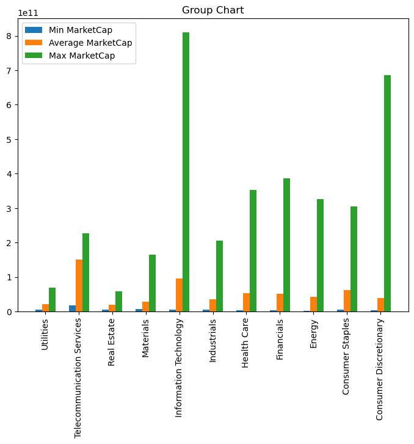

```python
# Stats of Market Cap grouped by Sectors
sectors = np.char.decode(report_1['Sector'])
x = np.arange(len(sectors))

min_MC = report_1['Min_MarketCap']
max_MC = report_1['Max_MarketCap']
avg_MC = report_1['Avg_MarketCap']

width = 0.20

a = plt.figure()
ax = a.add_axes([0,0,1,1])
ax.set_title("Group Chart")
ax.bar(x-0.2, min_MC, width)
ax.bar(x, avg_MC, width)
ax.bar(x+0.2, max_MC, width)

ax.legend(['Min MarketCap', 'Average MarketCap', 'Max MarketCap'],
          loc = 'upper left')

plt.xticks(x, sectors, rotation=90)
plt.show()
```

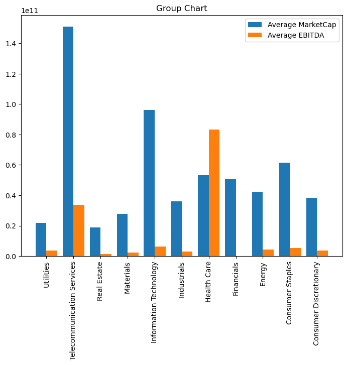

```python
# Means of Market Cap and EBITDA grouped by Sectors
sectors = np.char.decode(report_1['Sector'])
x = np.arange(len(sectors))

avg_MC = report_1['Avg_MarketCap']
avg_EB = report_1['Avg_EBITDA']

width = 0.4

a = plt.figure()
ax = a.add_axes([0,0,1,1])
ax.set_title("Group Chart")
ax.bar(x-0.2, avg_MC, width)
ax.bar(x+0.2, avg_EB, width)

ax.legend(['Average MarketCap', 'Average EBITDA'],
          loc = 'upper right')

plt.xticks(x, sectors, rotation=90)
plt.show()
```

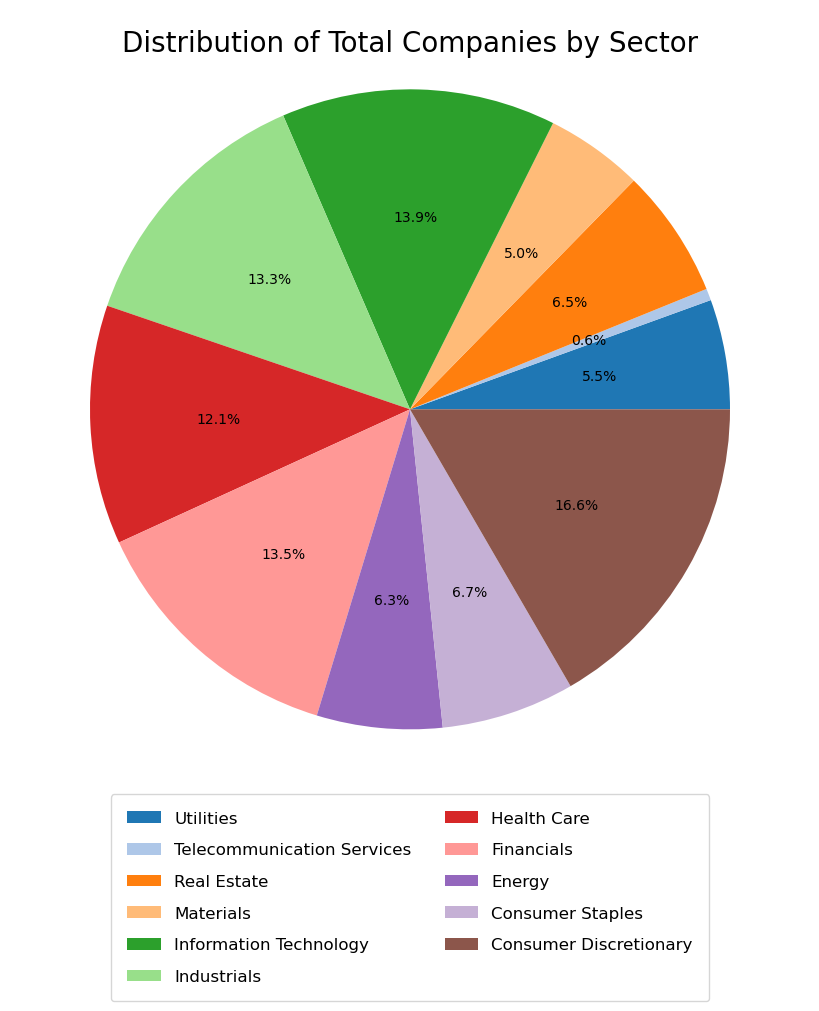

```python
# Visualize Sectors using Pie Chart
sectors = np.char.decode(report_1['Sector'])
sector_count = report_1['TotalCompanies']
cmap = plt.get_cmap("tab20")

a = plt.figure(figsize=(8,8))
ax = a.add_axes([0,0,1,1])
ax.set_title("Distribution of Total Companies by Sector", y=1.0, pad=-30, fontsize = 20)
ax.pie(sector_count, autopct='%1.1f%%', colors = cmap(np.arange(0,20,1)))
ax.legend(sectors, ncol=2,
          loc = 'lower center', bbox_to_anchor=(0.5,-0.25),
          borderpad=1, labelspacing=1, fontsize = 12)

plt.show()
```

#### Report 2: Top 10 Dividend Yield Companies. Report will show the top 10 companies symbol, name, associated sector, price, price earnings, and dividend yield.

```python
# Sort the Data for Dividend Yield
sorted_DY = np.sort(sp500_ud[~np.isnan(sp500_ud['DividendYield'])],
                    order='DividendYield')[::-1]
# Show the top 10 only
DY_TopTen = sorted_DY[0:10][['Sector','DividendYield']]

# Show each Sector
sect_col = np.unique(sp500_ud['Sector'])
```

```python
# Create defined structured array
report_2 = np.asarray([],
                       dtype = {'names': ('Sector', 'Symbol', 'Name',
                                          'Price', 'Price_Earnings',
                                          'DividendYield'),
                                'formats': ('S30', 'S5', 'S50',
                                            'f8', 'f8', 'f8')})
```

```python
# Inserting necessary data into Report 2
for sect in sect_col:
    count = 0

    rows = sp500_ud[np.where(sp500_ud['Sector'] == sect)]

    sorted_DY = np.sort(rows[~np.isnan(rows['DividendYield'])],
                        order='DividendYield')[::-1]
    top_ten = np.argwhere(sorted_DY[0:10]['DividendYield'])

    for i in top_ten:
        # print(sp500_ud[i])
        symbol = sorted_DY[i]['Symbol'].item()
        name = sorted_DY[i]['Name'].item()
        price = sorted_DY[i]['Price'].item()
        pe = sorted_DY[i]['Price_Earnings'].item()
        dy = sorted_DY[i]['DividendYield'].item()

        report_2 = np.insert(report_2, count, (sect, symbol, name, price, pe, dy))

    count += 1
```

```python
# Save Report 2
np.save(path+"SP500_Report2", report_2)
```

**REPORT 2**

```python
# Sort Report 2 by Sector and Name
sorted_report_2 = np.sort(report_2, order=['Sector', 'Name'])

# Print necessary columns for report
print(f"{'TOP 10 DIVIDEND YIELD COMPANIES BY SECTOR':^115}")
print(f"{'=':=^{115}}")
print(f"{'Sector':<30}{'Symbol':<10}{'Name':<35}{'Price':<10}{'Price Earnings':<15}{'Dividend Yield':<15}")
print(f"{'=':=^{115}}")
prev_sector = ' '

for sec_row in (sorted_report_2):

    sector = str(np.char.decode(sec_row['Sector'].item()))
    symbol = str(np.char.decode(sec_row['Symbol'].item()))
    name = str(np.char.decode(sec_row['Name'].item()))
    price = np.round(sec_row['Price'], decimals=2)
    pe = np.round(sec_row['Price_Earnings'], decimals=2)
    dy = np.round(sec_row['DividendYield'], decimals=2)

    if sector != prev_sector:
        prev_sector = sector
    else:
        sector = ' '

    print(f"\n{sector:<30}{symbol:<10}{name:<35}{price:<10}{pe:>12}{dy:>15}")
print(f"{'=':=^{115}}")
```

```
                                     TOP 10 DIVIDEND YIELD COMPANIES BY SECTOR
===================================================================================================================
Sector                        Symbol    Name                               Price     Price Earnings Dividend Yield
===================================================================================================================

Consumer Discretionary        F         Ford Motor                         10.43             5.89           6.78

                              GRMN      Garmin Ltd.                        61.13            21.23           3.23

                              GM        General Motors                     40.75             6.58           3.59

                              IPG       Interpublic Group                  21.34            15.46           3.38

                              KSS       Kohl's Corp.                       60.34            16.01            3.5

                              LB        L Brands Inc.                      47.77            12.77           4.89

                              LEG       Leggett & Platt                    43.99            17.88           3.15

                              M         Macy's Inc.                        24.0              7.67            6.1

                              OMC       Omnicom Group                      75.91            15.27           3.18

                              TGT       Target Corp.                       71.11            14.19           3.39

Consumer Staples              MO        Altria Group Inc                   64.05            18.89           3.95

                              ADM       Archer-Daniels-Midland Co          41.35            17.45           3.18

                              CPB       Campbell Soup                      44.83            14.84           3.12

                              KO        Coca-Cola Company (The)            43.1              22.8           3.32

                              GIS       General Mills                      53.99            17.53           3.59

                              K         Kellogg Co.                        65.98             16.5           3.36

                              KMB       Kimberly-Clark                     111.69           17.93           3.56

                              KHC       Kraft Heinz Co                     71.58            20.11            3.4
```

[output cut: 156 more lines]

```

                              DUK       Duke Energy                        74.32             16.7           4.78

                              EIX       Edison Int'l                       58.07            13.23           4.05

                              ETR       Entergy Corp.                      72.02            10.65           4.89

                              FE        FirstEnergy Corp                   30.64            11.18           4.67

                              PPL       PPL Corp.                          29.52            12.83           5.22

                              SCG       SCANA Corp                         35.6              8.75           6.68

                              SO        Southern Co.                       43.4             15.78           5.35
===================================================================================================================
```

**Report 2 Visual Outputs**

```python
# Horizontal Bar Chart: group by Sector, Name, top 5 Dividend Yield with symbol
# Save report 2 column names
report_2_col = report_2.dtype.names

for sector in np.unique(report_2['Sector']):
    print(np.char.decode(sector))
```

```
Consumer Discretionary
Consumer Staples
Energy
Financials
Health Care
Industrials
Information Technology
Materials
Real Estate
Telecommunication Services
Utilities
```

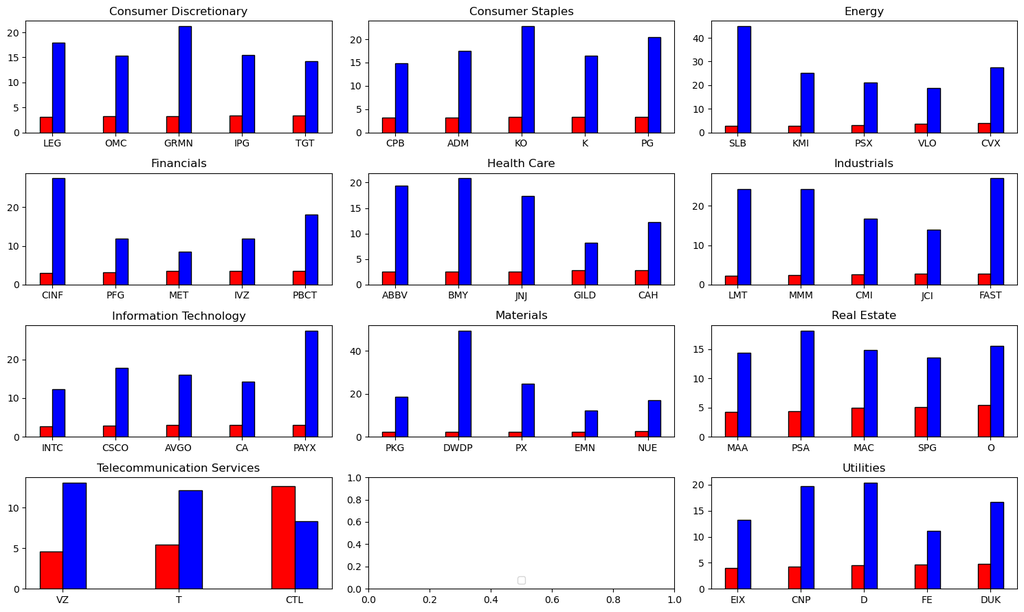

```python
fig, a = plt.subplots(4,3, figsize=(15,9))
x = np.arange(5)
width = 0.20

sec1 = report_2[np.where(report_2['Sector'] == b'Consumer Discretionary')][:5]
sec1_symb = (np.char.decode(sec1['Symbol'])).tolist()

a[0][0].set_title("Consumer Discretionary")
a[0][0].bar(x-0.1, sec1['DividendYield'], width,
            color='r', edgecolor='k')
a[0][0].bar(x+0.1, sec1['Price_Earnings'], width,
            color='b', edgecolor='k')
a[0][0].set_xticks(x)
a[0][0].set_xticklabels(sec1_symb)

sec2 = report_2[np.where(report_2['Sector'] == b'Consumer Staples')][:5]
sec2_symb = (np.char.decode(sec2['Symbol'])).tolist()

a[0][1].set_title("Consumer Staples")
a[0][1].bar(x-0.1, sec2['DividendYield'], width,
            color='r', edgecolor='k')
a[0][1].bar(x+0.1, sec2['Price_Earnings'], width,
            color='b', edgecolor='k')
a[0][1].set_xticks(x)
a[0][1].set_xticklabels(sec2_symb)

sec3 = report_2[np.where(report_2['Sector'] == b'Energy')][:5]
sec3_symb = (np.char.decode(sec3['Symbol'])).tolist()

a[0][2].set_title("Energy")
a[0][2].bar(x-0.1, sec3['DividendYield'], width,
            color='r', edgecolor='k')
a[0][2].bar(x+0.1, sec3['Price_Earnings'], width,
            color='b', edgecolor='k')
a[0][2].set_xticks(x)
a[0][2].set_xticklabels(sec3_symb)

sec4 = report_2[np.where(report_2['Sector'] == b'Financials')][:5]
sec4_symb = (np.char.decode(sec4['Symbol'])).tolist()

a[1][0].set_title("Financials")
a[1][0].bar(x-0.1, sec4['DividendYield'], width,
            color='r', edgecolor='k')
a[1][0].bar(x+0.1, sec4['Price_Earnings'], width,
            color='b', edgecolor='k')
a[1][0].set_xticks(x)
a[1][0].set_xticklabels(sec4_symb)

sec5 = report_2[np.where(report_2['Sector'] == b'Health Care')][:5]
sec5_symb = (np.char.decode(sec5['Symbol'])).tolist()

a[1][1].set_title("Health Care")
a[1][1].bar(x-0.1, sec5['DividendYield'], width,
            color='r', edgecolor='k')
a[1][1].bar(x+0.1, sec5['Price_Earnings'], width,
            color='b', edgecolor='k')
a[1][1].set_xticks(x)
a[1][1].set_xticklabels(sec5_symb)

sec6 = report_2[np.where(report_2['Sector'] == b'Industrials')][:5]
sec6_symb = (np.char.decode(sec6['Symbol'])).tolist()

a[1][2].set_title("Industrials")
a[1][2].bar(x-0.1, sec6['DividendYield'], width,
            color='r', edgecolor='k')
a[1][2].bar(x+0.1, sec6['Price_Earnings'], width,
            color='b', edgecolor='k')
a[1][2].set_xticks(x)
a[1][2].set_xticklabels(sec6_symb)

sec7 = report_2[np.where(report_2['Sector'] == b'Information Technology')][:5]
sec7_symb = (np.char.decode(sec7['Symbol'])).tolist()

a[2][0].set_title("Information Technology")
a[2][0].bar(x-0.1, sec7['DividendYield'], width,
            color='r', edgecolor='k')
a[2][0].bar(x+0.1, sec7['Price_Earnings'], width,
            color='b', edgecolor='k')
a[2][0].set_xticks(x)
a[2][0].set_xticklabels(sec7_symb)

sec8 = report_2[np.where(report_2['Sector'] == b'Materials')][:5]
sec8_symb = (np.char.decode(sec8['Symbol'])).tolist()

a[2][1].set_title("Materials")
a[2][1].bar(x-0.1, sec8['DividendYield'], width,
            color='r', edgecolor='k')
a[2][1].bar(x+0.1, sec8['Price_Earnings'], width,
            color='b', edgecolor='k')
a[2][1].set_xticks(x)
a[2][1].set_xticklabels(sec8_symb)

sec9 = report_2[np.where(report_2['Sector'] == b'Real Estate')][:5]
sec9_symb = (np.char.decode(sec9['Symbol'])).tolist()

a[2][2].set_title("Real Estate")
a[2][2].bar(x-0.1, sec9['DividendYield'], width,
            color='r', edgecolor='k')
a[2][2].bar(x+0.1, sec9['Price_Earnings'], width,
            color='b', edgecolor='k')
a[2][2].set_xticks(x)
a[2][2].set_xticklabels(sec9_symb)

sec10 = report_2[np.where(report_2['Sector'] == b'Telecommunication Services')]
sec10_symb = (np.char.decode(sec10['Symbol'])).tolist()
tc = np.arange(len(sec10))

a[3][0].set_title("Telecommunication Services")
a[3][0].bar(tc-0.1, sec10['DividendYield'], width,
            color='r', edgecolor='k')
a[3][0].bar(tc+0.1, sec10['Price_Earnings'], width,
            color='b', edgecolor='k')
a[3][0].set_xticks(tc)
a[3][0].set_xticklabels(sec10_symb)

sec11 = report_2[np.where(report_2['Sector'] == b'Utilities')][:5]
sec11_symb = (np.char.decode(sec11['Symbol'])).tolist()

a[3][2].set_title("Utilities")
a[3][2].bar(x-0.1, sec11['DividendYield'], width,
            color='r', edgecolor='k')
a[3][2].bar(x+0.1, sec11['Price_Earnings'], width,
            color='b', edgecolor='k')
a[3][2].set_xticks(x)
a[3][2].set_xticklabels(sec11_symb)

a[3][1].legend(['Dividend Yield', 'P/E'], loc = 'lower center', ncol=2)
plt.tight_layout()
plt.show()
```

```python
### ALTERNATIVE METHOD ###
```

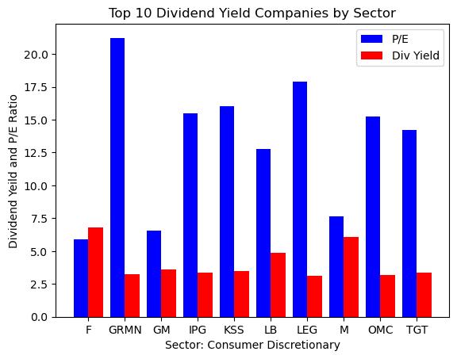

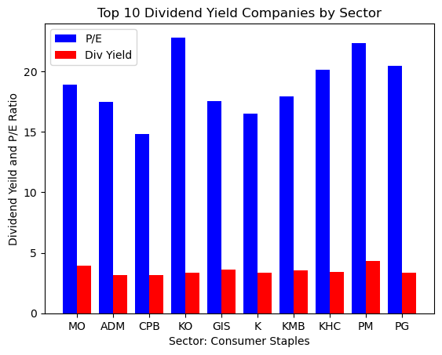

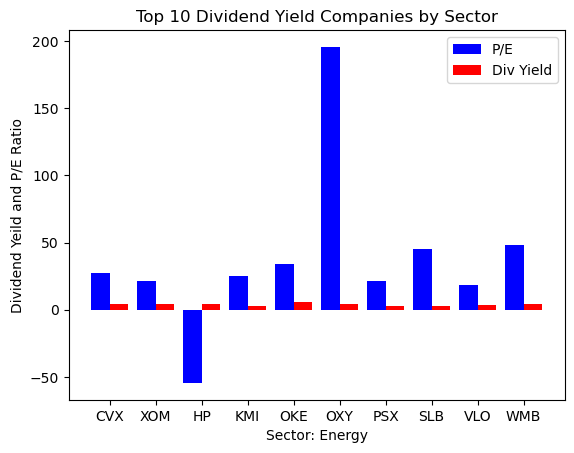

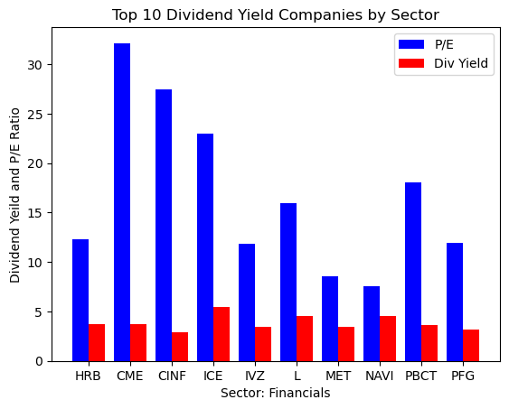

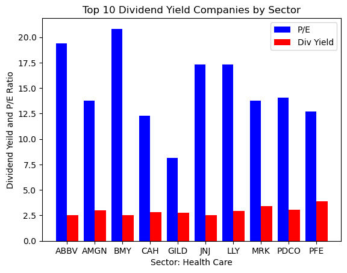

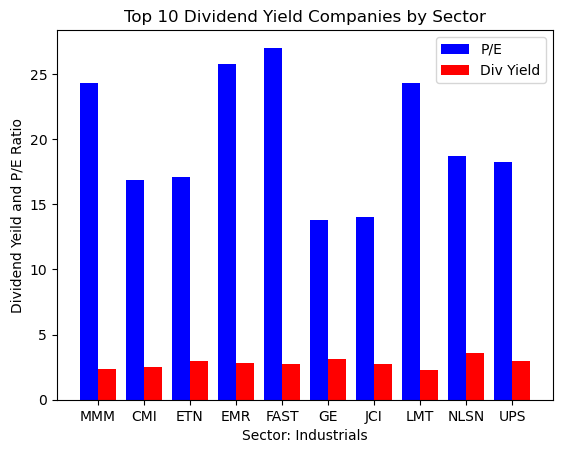

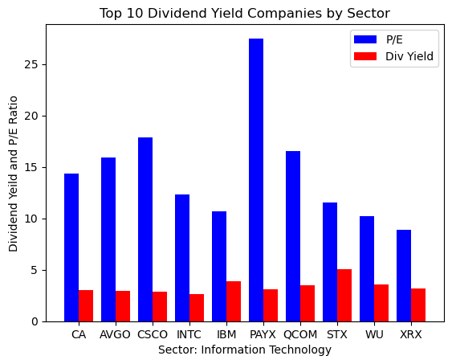

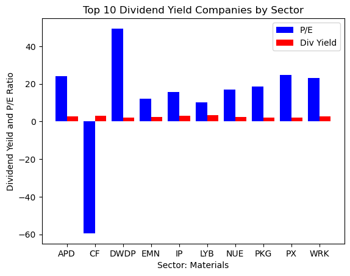

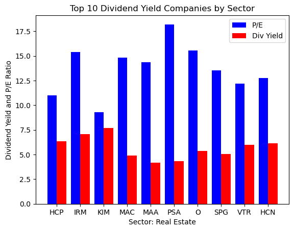

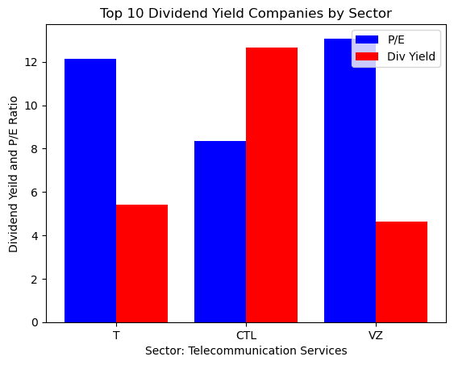

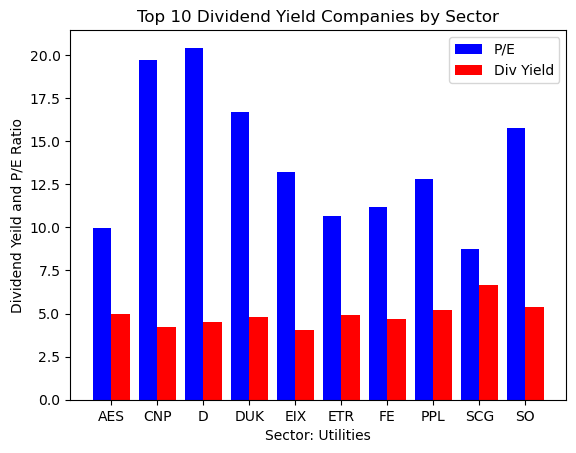

```python
sect_colms = np.unique(sorted_report_2['Sector'])
sect_count = len(sect_colms)
sect_list = []

for i in range(len(sect_colms)):
    sect_list.append(str(np.char.decode(sect_colms[i].item())))

for i in range(len(sect_colms)):
    sectsymb = sorted_report_2[sorted_report_2['Sector'] == sect_colms[i]] ['Symbol']
    sectdivd = sorted_report_2[sorted_report_2['Sector'] == sect_colms[i]] ['DividendYield']
    sectpe = sorted_report_2[sorted_report_2['Sector'] == sect_colms[i]] ['Price_Earnings']

    # Decode numpy string to python string
    symb_list = []
    for j in range(len(sectsymb)):
        symb_list.append(str(np.char.decode(sectsymb[j].item())))

    X_Sector = symb_list
    Y_PE = sectpe
    Z_Div = sectdivd
    X_axis = np.arange(len(X_Sector))


    plt.bar(X_axis - 0.2, Y_PE, 0.4, label = 'P/E', color='b')
    plt.bar(X_axis + 0.2, Z_Div, 0.4, label = 'Div Yield', color='r')

    plt.xticks(X_axis, X_Sector)
    sectlabel = str(np.char.decode(sect_colms[i].item()))
    sectlabel = 'Sector: '+sectlabel
    plt.xlabel(sectlabel)
    plt.ylabel("Dividend Yeild and P/E Ratio")
    plt.title("Top 10 Dividend Yield Companies by Sector")
    plt.legend()
    plt.show()
```

#### Report 3: 5 Companies with the lowest 52 Week Change. Report will show associated sector, symbol, name, price, price earnings, 52 week high, 52 week low, 52 week range (max - min)

```python
# Sort the data by Sector
sect_col = np.unique(sp500_ud['Sector'])

# Create defined structured array
report_3 = np.asarray([],
                       dtype = {'names': ('Sector', 'Symbol', 'Name',
                                          'Price', 'Price_Earnings',
                                          '52WeekHigh', '52WeekLow', '52WeekRange'),
                                'formats': ('S30', 'S5', 'S50',
                                            'f8', 'f8', 'f8', 'f8', 'f8')})
```

```python
# Inserting necessary data into Report 3
for sect in sect_col:
    count = 0
    rows = sp500_ud[np.where(sp500_ud['Sector'] == sect)]

    for i in rows:
        week52_high = i['52WeekHigh']
        week52_low = i['52WeekLow']
        week52_range = week52_high - week52_low

        symbol = i['Symbol']
        name = i['Name']
        price = i['Price']
        pe = i['Price_Earnings']

        report_3 = np.insert(report_3, count, (sect, symbol, name, price, pe, week52_high, week52_low, week52_range))

    count += 1
```

```python
# Sort report_3 by Sector and 52WeekRange
report_3 = np.sort(report_3, order=['Sector', '52WeekRange'])
```

```python
# Save report 3
np.save(path+"SP500_Report3", report_3)
```

**REPORT 3**

```python
# Print Top 5 Companies by Sector with the least 52 week price change
print(f"{'TOP 5 COMPANIES BY SECTOR WITH THE LEAST 52 WEEK PRICE CHANGE':^115}")
print(f"{'=':=^{115}}")
print(f"{'Sector':<30}{'Symbol':<8}{'Name':<35}{'Price':<8}{'P/E':<5}{'52WkHigh':<10}{'52WkLow':<10}{'52WkRange':<10}")
print(f"{'=':=^{115}}")

prev_sector = ' '

for sect in sect_col:
    #print(sect)
    rows = report_3[np.where(report_3['Sector'] == sect)]
    rows[:5]['Symbol']

    for i in rows[:5]:
        #print(i)
        sector = str(np.char.decode(i['Sector']))
        symbol = str(np.char.decode(i['Symbol']))
        name = str(np.char.decode(i['Name']))
        price = np.round(i['Price'], decimals=2)
        pe = np.round(i['Price_Earnings'], decimals=2)
        wk52_high = np.round(i['52WeekHigh'], decimals=2)
        wk52_low = np.round(i['52WeekLow'], decimals=2)
        wk52_range = np.round(i['52WeekRange'], decimals=2)

        if sector != prev_sector:
            prev_sector = sector
        else:
            sector = ' '

        #print(sector, symbol, name, price, pe, wk52_high, wk52_low, wk52_range)
        print(f"\n{sector:<30}{symbol:<8}{name:<35}{price:<8}{pe:<8}{wk52_high:<10}{wk52_low:<10}{wk52_range:<10}")
print(f"{'=':=^{115}}")
```

```
                           TOP 5 COMPANIES BY SECTOR WITH THE LEAST 52 WEEK PRICE CHANGE
===================================================================================================================
Sector                        Symbol  Name                               Price   P/E  52WkHigh  52WkLow   52WkRange
===================================================================================================================

Consumer Discretionary        F       Ford Motor                         10.43   5.89    13.48     10.19     3.29

                              NWSA    News Corp. Class A                 15.65   43.47   17.29     12.0      5.29

                              NWS     News Corp. Class B                 15.85   44.03   17.7      12.35     5.35

                              HBI     Hanesbrands Inc                    19.57   10.04   25.73     18.9      6.83

                              IPG     Interpublic Group                  21.34   15.46   25.71     18.3      7.41

Consumer Staples              COTY    "Coty, Inc"                        19.96   24.64   21.18     14.24     6.94

                              MDLZ    Mondelez International             42.68   19.85   47.23     39.19     8.04

                              HRL     Hormel Foods Corp.                 32.21   20.39   38.0      29.75     8.25

                              KO      Coca-Cola Company (The)            43.1    22.8    48.62     40.22     8.4

                              ADM     Archer-Daniels-Midland Co          41.35   17.45   47.44     38.59     8.85

Energy                        CHK     Chesapeake Energy                  2.82    4.7     6.59      2.8       3.79

                              KMI     Kinder Morgan                      16.8    25.07   22.75     16.56     6.19

                              WMB     Williams Cos.                      28.56   48.41   33.67     26.82     6.85

                              COG     Cabot Oil & Gas                    23.01   60.55   29.57     21.4      8.17

                              MRO     Marathon Oil Corp.                 15.68   -32.0   19.52     10.55     8.97

Financials                    PBCT    People's United Financial          18.56   18.02   20.14     15.96     4.18

                              HBAN    Huntington Bancshares              15.1    15.41   16.53     12.14     4.39

                              NAVI    Navient                            13.38   7.56    16.97     11.48     5.49
```

[output cut: 56 more lines]

```

                              VZ      Verizon Communications             49.04   13.08   54.77     42.8      11.97

                              CTL     CenturyLink Inc                    16.2    8.35    27.61     13.16     14.45

Utilities                     AES     AES Corp                           10.06   9.96    12.05     10.0      2.05

                              CNP     CenterPoint Energy                 25.85   19.73   30.45     25.51     4.94

                              NI      NiSource Inc.                      22.51   19.57   27.76     21.93     5.83

                              FE      FirstEnergy Corp                   30.64   11.18   35.22     27.93     7.29

                              LNT     Alliant Energy Corp                37.14   19.86   45.55     36.84     8.71
===================================================================================================================
```

**Report 3 Visual Outputs**

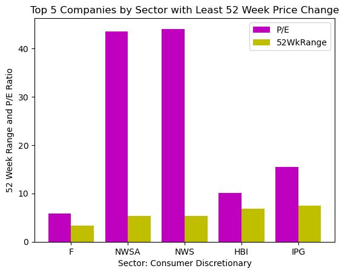

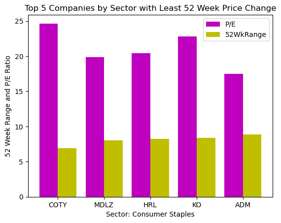

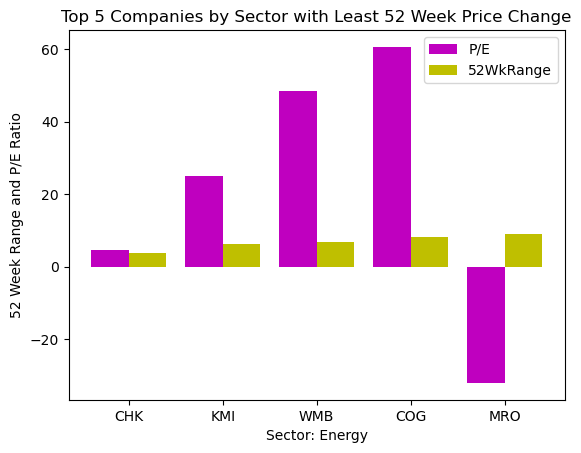

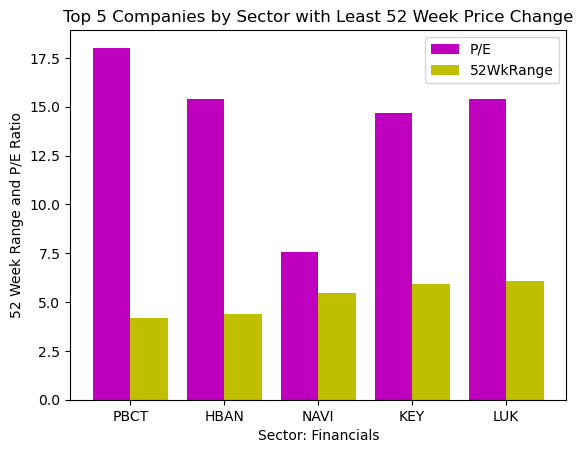

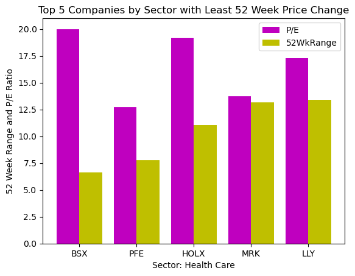

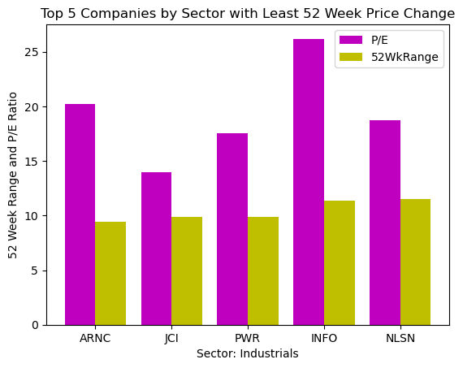

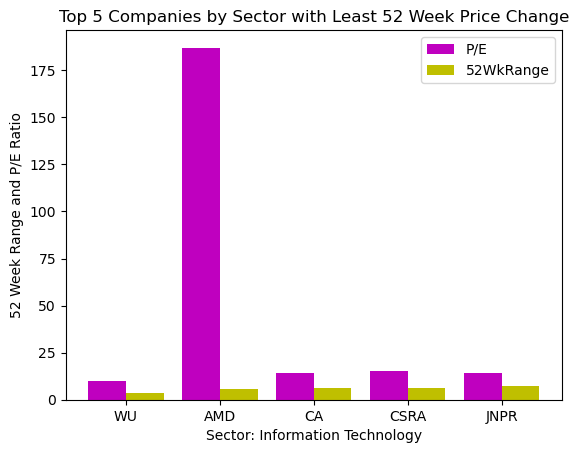

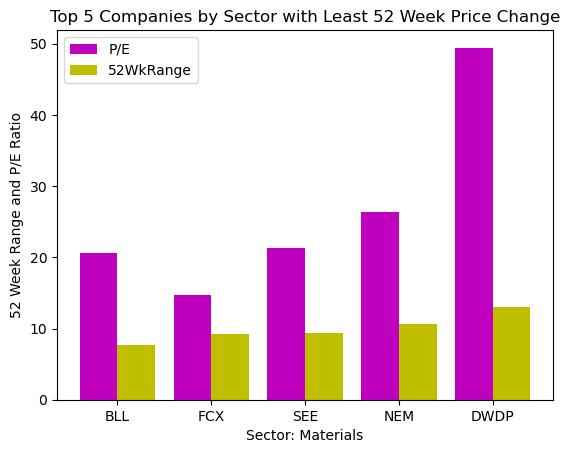

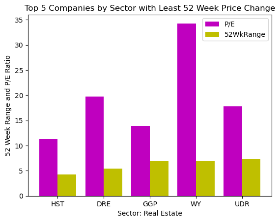

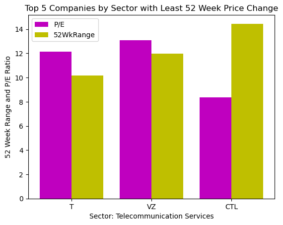

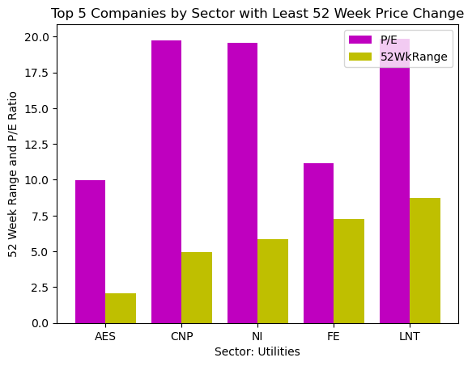

```python
sect_colms = np.unique(report_3['Sector'])
sect_count = len(sect_colms)
sect_list = []

for sect in (sect_col):
    rows = report_3[report_3['Sector'] == sect][:5]

    symb_list = []
    pe_list = []
    wkrange_list = []

    for i in (rows):

        sectsymb = i['Symbol']
        sect52range = i['52WeekRange']
        sectpe = i['Price_Earnings']

        symb_list.append(str(np.char.decode(sectsymb)))
        pe_list.append(sectpe)
        wkrange_list.append(sect52range)

    X_Sector = symb_list
    Y_PE = pe_list
    Z_Range = wkrange_list
    X_axis = np.arange(len(X_Sector))

    plt.bar(X_axis - 0.2, Y_PE, 0.4, label = 'P/E', color='m')
    plt.bar(X_axis + 0.2, Z_Range, 0.4, label = '52WkRange', color='y')

    plt.xticks(X_axis, X_Sector)
    sectlabel = str(np.char.decode(sect))
    sectlabel = 'Sector: '+sectlabel
    plt.xlabel(sectlabel)
    plt.ylabel("52 Week Range and P/E Ratio")
    plt.title("Top 5 Companies by Sector with Least 52 Week Price Change")
    plt.legend()
    plt.show()
```